# Distributions: Discrete and Continuous

This project will help us visualize various functions attached to the different distributions learned in class.

# 1 Binomial distribution.

## 1.1 Probability Mass Function

We will plot the probability mass function for the binomial distribution Bin(n, p). Note: 1) The values for this random variable are 0, 1, 2, …, n. 2) The density plot will have a bar of height P(X=k), at the point ‘k’ on the x-axis. 3) In the plot include a vertical line at the expected value of Bin(n,p).

Write a function plot_binom, that takes input values: n and p, and returns the density plot of Bin(n,p).

```r
plot_binom_pmf <- function(n, p) {
  x <- 0:n
  binomvals <- dbinom(x, size = n, prob = p)
  plot(x, binomvals, type = "h", lwd = 5,
       main = paste("Binomial density for", p),
       xlab = "x", ylab = "P(X=x)")
  abline(v = n * p, col = 'red', lwd = 4)
}
```

Fix n = 40. Compute plots of the pmf for the following values of p: 0.05, 0.1, 0.4, 0.6, 0.9, 0.95. Have all the plots on the same frame.

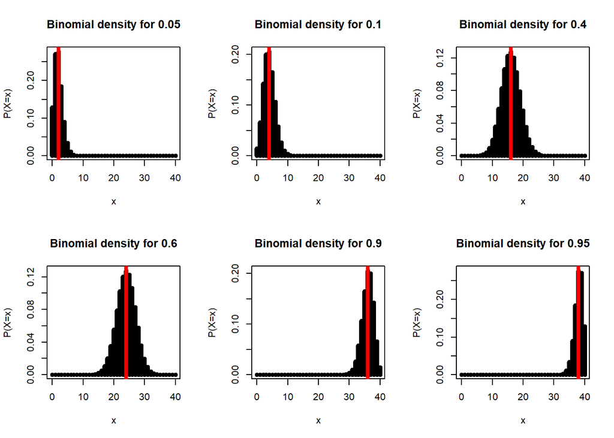

```r
par(mfrow = c(2, 3))

plot_binom_pmf(40, 0.05)
plot_binom_pmf(40, 0.1)
plot_binom_pmf(40, 0.4)
plot_binom_pmf(40, 0.6)
plot_binom_pmf(40, 0.9)
plot_binom_pmf(40, 0.95)
```

## 1.2 Cumulative Distribution Functions

Write a function to plot the cumulative distribution function of the Binomial random variable, call it ‘plot_binom_cdf’.

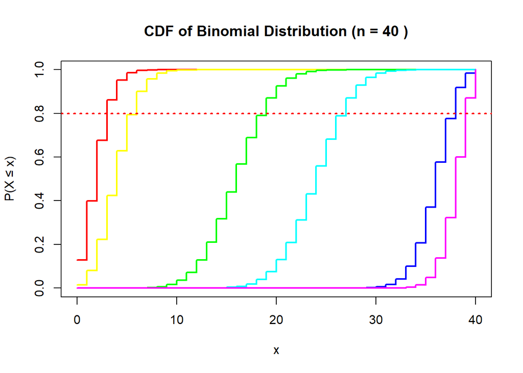

```r
plot_binom_cdf <- function(n = 40) {
  p_values <- c(0.05, 0.1, 0.4, 0.6, 0.9, 0.95)
  x <- 0:n
  colors <- rainbow(length(p_values))

  plot(x, pbinom(x, size = n, prob = p_values[1]), type = "s", lwd = 2,
       col = colors[1], ylim = c(0, 1),
       main = paste("CDF of Binomial Distribution (n =", n, ")"),
       xlab = "x", ylab = "P(X ≤ x)")

  for (i in 2:length(p_values)) {
    lines(x, pbinom(x, size = n, prob = p_values[i]), type = "s", col = colors[i], lwd = 2)
  }
  abline(h = 0.8, col = "red", lty = "dotted", lwd = 2)

}

plot_binom_cdf(40)
```

Fix n = 40. Compute plots of the of the graphs cdf for the following values of p: 0.05, 0.1, 0.4, 0.6, 0.9, 0.95. Have all graphs on the same plot (with different colors). Draw a horizontal line at $y=0.8$.

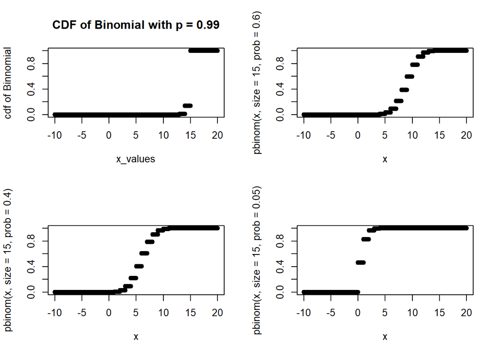

```r
x <- seq(-10, 20, length.out = 1000)
#plot(x, pbinom(x, size = 15, prob = 0.8))

par(mfrow = c(2,2))
plot(x, pbinom(x, size = 15, prob = 0.99),
     main = "CDF of Binomial with p = 0.99",
     xlab = "x_values",
     ylab = "cdf of Binnomial")
plot(x, pbinom(x, size = 15, prob = 0.6))
plot(x, pbinom(x, size = 15, prob = 0.4))
plot(x, pbinom(x, size = 15, prob = 0.05))
```

# 2 Poisson Distribution.

## 2.1 Probability Mass Functions

We will plot the mass function for the Poison distribution Pois(mu). Note: 1) The values for this random variable are: 0, 1, 2, 3, …. 2) The density plot will have a bar of height P(X=k), at the point ‘k’ on the x-axis. 3) Since most of the densities will be concentrated at lower values of k, we will fix a large enough value of n, say n = 100, when drawing the density plots. 3) In the plot include a vertical line at the expected value of Pois(mu).

The following function is a first jab at writing a function to plot the pmf of the Poisson Distribution

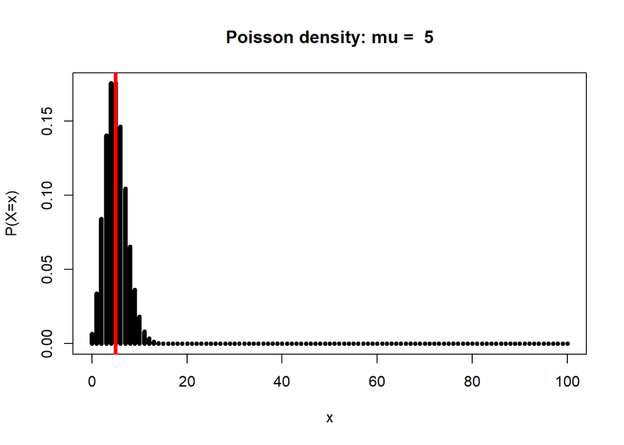

```r
n <- 100
plot_pois_pmf <- function(mu){
  x <- 0:n
  pois <- dpois(x, lambda = mu)
  plot(x, pois, type = "h", lwd = 5,
       main = paste("Poisson density: mu = ", mu),
       xlab = "x", ylab = "P(X=x)")
  abline(v = mu, col = 'red', lwd = 4)
}

plot_pois_pmf(5)
```

For the following values of mu compute the plots for the pmf of the Poisson distribution: mu: 0.5, 1, 5, 8, 20, 50. Have all plots on the same frame.

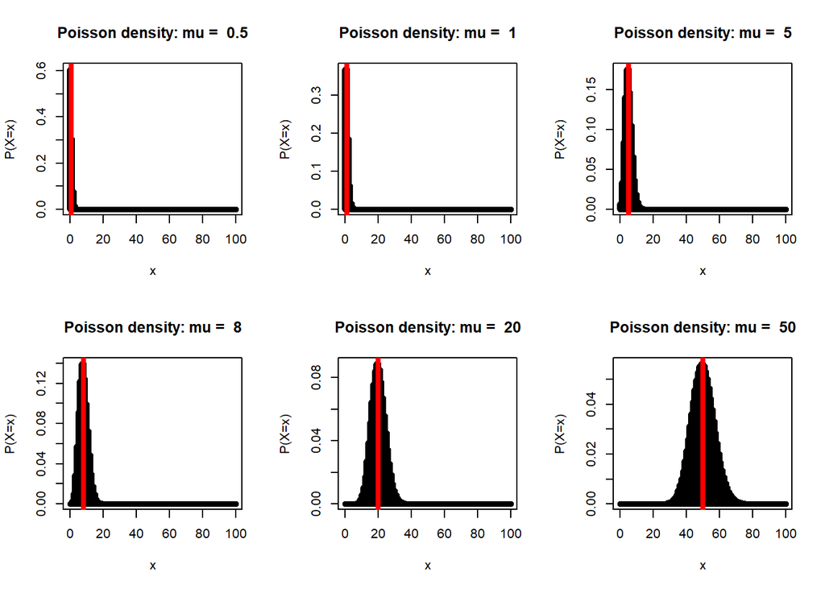

```r
par(mfrow = c(2, 3))

plot_pois_pmf(0.5)
plot_pois_pmf(1)
plot_pois_pmf(5)
plot_pois_pmf(8)
plot_pois_pmf(20)
plot_pois_pmf(50)
```

## 2.2 Cumulative Distribution Functions

Write a function ‘plot_pois_cdf’ that takes input $\mu$ and returns the plot of the cdf of the $\text{Pois}(\mu)$.

```r
plot_pois_cdf <- function(mu) {
  x <- 0:ceiling(mu + 3 * sqrt(mu))

  cdf_vals <- ppois(x, lambda = mu)

  plot(x, cdf_vals, type = "s", lwd = 2,
       main = paste("CDF of Pois(µ =", mu, ")"),
       xlab = "x", ylab = "P(X ≤ x)",
       ylim = c(0, 1))

  abline(h = seq(0, 1, by = 0.1), col = "black", lty = "solid")
}
```

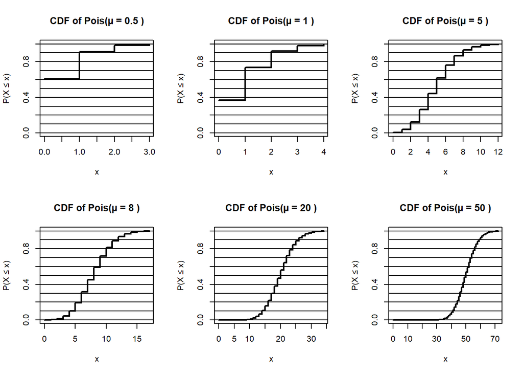

```r
par(mfrow = c(2, 3))

plot_pois_cdf(.5)
plot_pois_cdf(1)
plot_pois_cdf(5)
plot_pois_cdf(8)
plot_pois_cdf(20)
plot_pois_cdf(50)
```

# 3 Comparing Poison with Binomial

We say two random variables $X$ and $Y$ are identically distributed if they have the same cumulative distribution functions, that is

$$F_X(u) = F_Y(u) \quad \quad \forall x\in
\mathbb{R}$$
We can use the Poisson distribution to approximate the Binomial distribution. Let’s visualize it now:

Plot the graphs of the cdf of $\text{Binom}(n=10, p=0.5)$ and $\text{Pois}(\mu= 5)$ on the same plot.

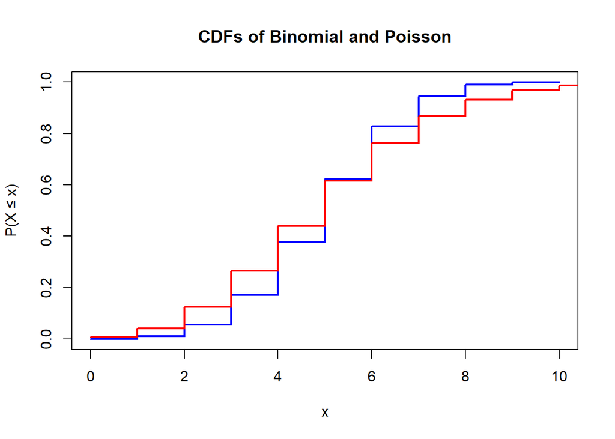

```r
plot_binom_pois_cdf <- function(n, p, mu) {
  x_binom <- 0:n  #
  cdf_binom <- pbinom(x_binom, size = n, prob = p)

  x_pois <- 0:ceiling(mu + 3 * sqrt(mu))
  cdf_pois <- ppois(x_pois, lambda = mu)


  plot(x_binom, cdf_binom, type = "s", lwd = 2, col = "blue",
       main = paste("CDFs of Binomial and Poisson"),
       xlab = "x", ylab = "P(X ≤ x)", ylim = c(0, 1))

  lines(x_pois, cdf_pois, type = "s", lwd = 2, col = "red")

}

plot_binom_pois_cdf(n = 10, p = 0.5, mu = 5)
```

Now plot the graphs of the cdf of $\text{Binom}(n= 1000, p= 0.005)$ and $\text{Pois}(\mu= 5)$.

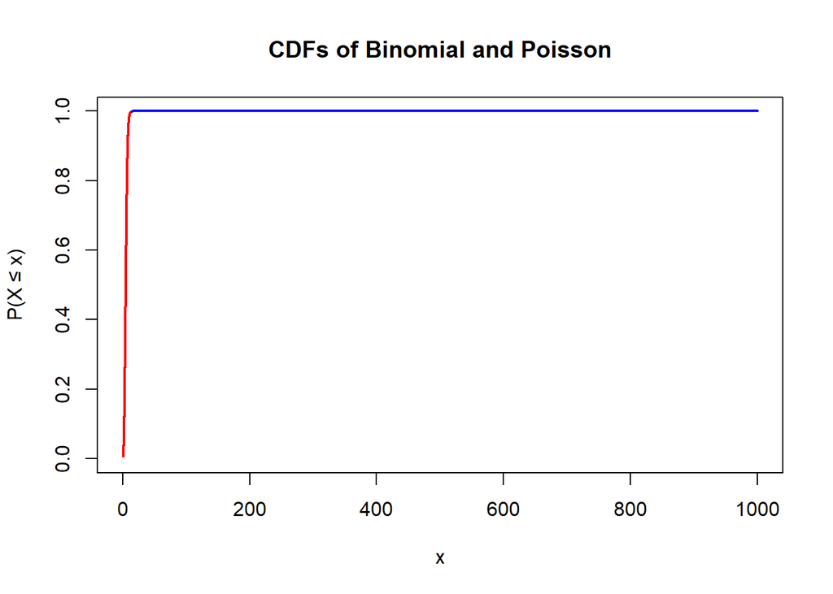

```r
plot_binom_pois_cdf(1000, 0.005, 5)
```

Do the graphs overlap? Why/Why not? YOUR ANSWER: Yes, since it is a larger range to estimate, although it does not overlap at the beginning.

# 4 Normal Distibution

In this section we will explore the normal distribution.

## 4.1 Fixed mean, varying standard deviation

### 4.1.1 Plotting Densities

Set $\mu = 5$. For values of $\sigma$ given by $0.2, 0.4, 0.8, 1, 1.3, 1.8, 2$, plot the densities of $N(\mu, \sigma)$ in the same plot. It might help if (1) you have the densities of $N(\mu = 5, \sigma = 0.2)$ and $N(\mu = 5, \sigma = 2)$ to be blue in color and the rest to be red. (2) choose appropriate limits for the x-axis (use x_lim parameter in the plot funtion) and y-axis (use y_lim).

Method 1: Using ‘plot’ function from R-base

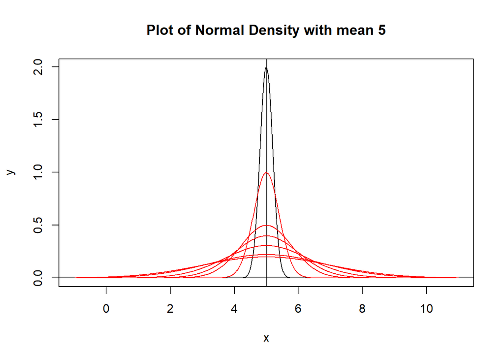

```r
mu <- 5
sds <- c(0.4, 0.8, 1, 1.3, 1.8, 2)

x <- seq(-6, 6, length.out = 1000)
x <- 5+x
y <- dnorm(x, mean = 5, sd=0.2)

plot(x, y,
     type = 'l',
     main= "Plot of Normal Density with mean 5")
abline(v=5, h=0)
for(std in sds){
  y_temp <- dnorm(x, mean = 5, sd=std)
  lines(x, y_temp,
        type = 'l',
        col = 'red')
}
```

Method 2: Using ggplot

```r
library(tidyverse)
x <- seq(-6, 6, length.out = 1000)
x <- 5+x
```

```r
y_0.2 <- dnorm(x, mean= 5, sd = 0.2)
y_0.4 <- dnorm(x, mean= 5, sd = 0.4)
y_0.8 <- dnorm(x, mean= 5, sd = 0.8)
y_1 <- dnorm(x, mean= 5, sd = 1)
y_1.3 <- dnorm(x, mean= 5, sd = 1.3)
y_1.8 <- dnorm(x, mean = 5, sd = 1.8)
y_2 <- dnorm(x, mean= 5, sd = 2)

plot_data_pdf <- data.frame(x,y_0.2,y_0.4,y_0.8,y_1,y_1.3, y_1.8, y_2)
```

```r
plot_data_pdf_new <- pivot_longer(plot_data_pdf,
                                  cols = c(y_0.2,y_0.4,y_0.8,y_1,y_1.3, y_1.8, y_2),
                                  names_to = "std_devs"
                                  )
```

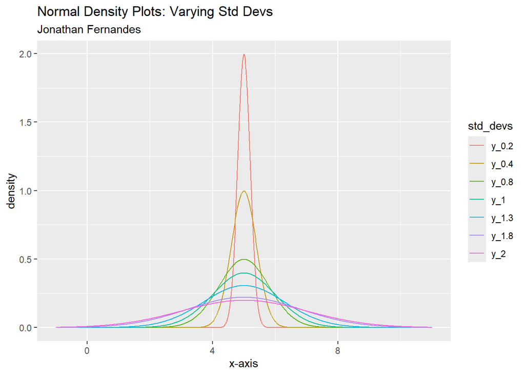

```r
ggplot(data = plot_data_pdf_new,
  aes(x = x,
      y = value,
      group = std_devs,
      color = std_devs))+
  geom_line()+
  labs(title = "Normal Density Plots: Varying Std Devs",
       subtitle = "Jonathan Fernandes",
       x = "x-axis",
       y = "density")
```

What do you notice about the plot? Comment about how the width changes. The width seems to be creater as it squeeces down, most likely to compensate for having the same area.

### 4.1.2 Plotting Cummulative Distribution Functions

Set $\mu = 5$. For values of $\sigma$ given by $0.2, 0.4, 0.8, 1, 1.3, 1.8, 2$, plot the cummulative distribution function of $N(\mu, \sigma)$ in the same plot. It might help if (1) you have the cdf of $N(\mu = 5, \sigma = 0.2)$ and $N(\mu = 5, \sigma = 2)$ to be blue in color and the rest to be red. (2) choose appropriate limits for the x-axis (use x_lim parameter in the plot funtion) and y-axis (use y_lim).

```r
z_0.2 <- pnorm(x, mean= 5, sd = 0.2)
z_0.4 <- pnorm(x, mean= 5, sd = 0.4)
z_0.8 <- pnorm(x, mean= 5, sd = 0.8)
z_1 <- pnorm(x, mean= 5, sd = 1)
z_1.3 <- pnorm(x, mean= 5, sd = 1.3)
z_1.8 <- pnorm(x, mean = 5, sd = 1.8)
z_2 <- pnorm(x, mean= 5, sd = 2)

plot_data_cdf <- data.frame(x,z_0.2,z_0.4,z_0.8,z_1,z_1.3, z_1.8, z_2)
```

```r
plot_data_cdf_new <- pivot_longer(plot_data_cdf,
                                  cols = c(z_0.2,z_0.4,z_0.8,z_1,z_1.3, z_1.8, z_2),
                                  names_to = "std_devs"
                                  )
```

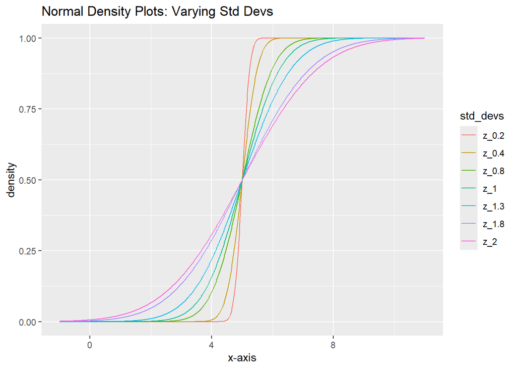

```r
ggplot(data = plot_data_cdf_new,
  aes(x = x,
      y = value,
      group = std_devs,
      color = std_devs))+
  geom_line()+
  labs(title = "Normal Density Plots: Varying Std Devs",
       x = "x-axis",
       y = "density")
```

What information does the point of intersection of two cdfs give us? Lets us see equivalent probabilities which allows us to visualize when one is lower than the other.

## 4.2 Varying mean, fixed standard deviation

### 4.2.1 Plotting Densities

Set $\sigma = 0.4$. For values of $\mu$ given by $-1, -0.5, 0, 0.4, 0.9, 2.5, 4$ plot the densities of $N(\mu, \sigma)$ in the same plot. You might need to choose appropriate limits for the x-axis.

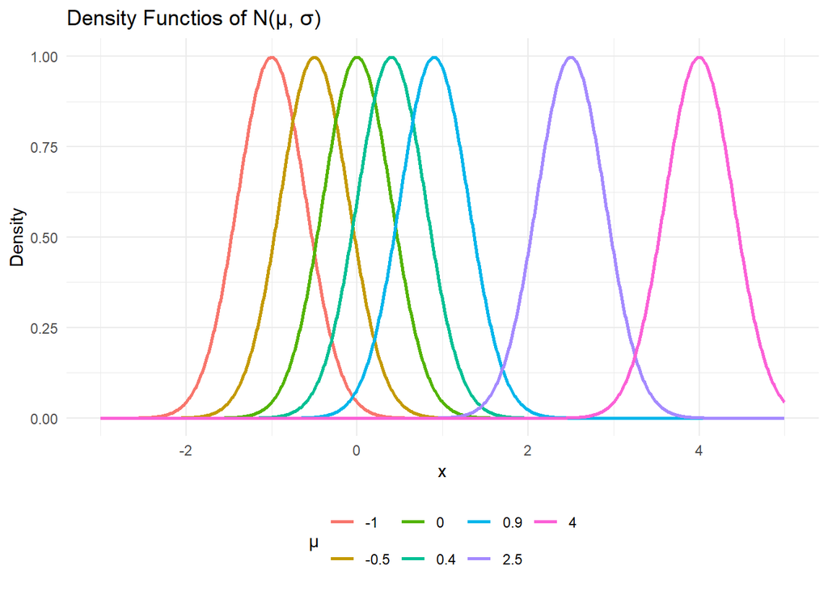

```r
library(ggplot2)

plot_normal_density <- function(mu_values, sigma) {
  x_values <- seq(-3, 5, length.out = 1000)

  density_data <- data.frame(
    x = rep(x_values, length(mu_values)),
    mu = rep(mu_values, each = length(x_values)),
    density = unlist(lapply(mu_values, function(mu) dnorm(x_values, mean = mu, sd = sigma)))
  )

  # Plot
  ggplot(density_data, aes(x = x, y = density, color = as.factor(mu))) +
    geom_line(size = 1) +
    labs(title = "Density Functios of N(μ, σ)", x = "x", y = "Density", color = "μ") +
    xlim(-3, 5) +
    ylim(0, 1) +
    theme_minimal() +
    theme(legend.position = "bottom")
}

mu_values <- c(-1, -0.5, 0, 0.4, 0.9, 2.5, 4)
sigma <- 0.4
plot_normal_density(mu_values, sigma)
```

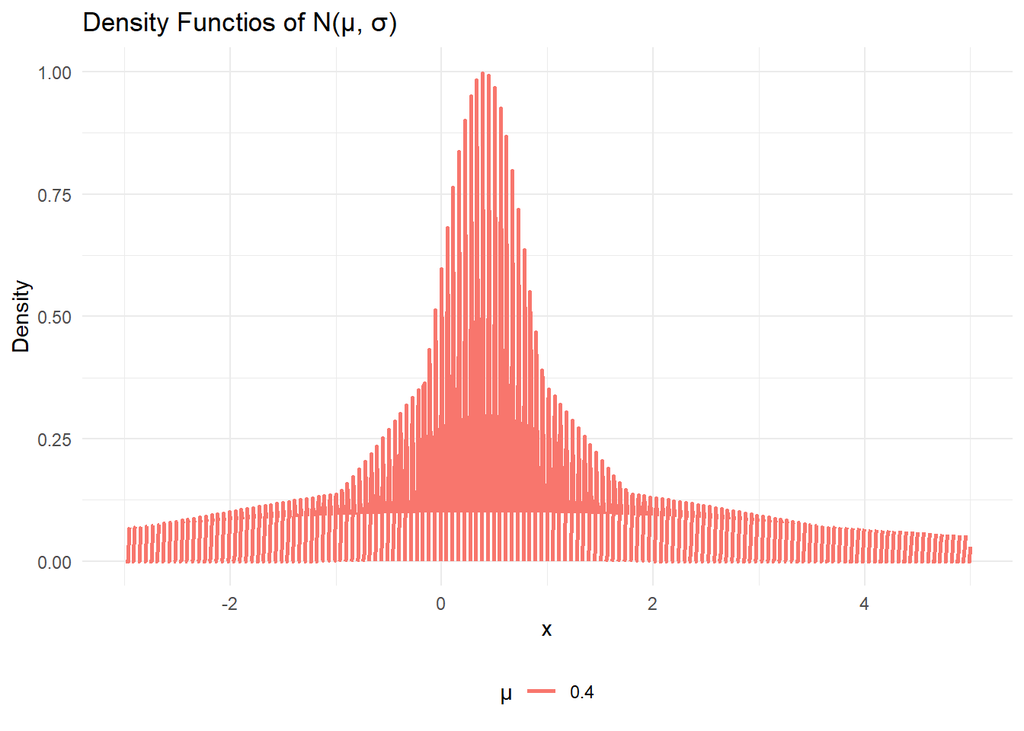

```r
sigma <- c(-1, -0.5, 0, 0.4, 0.9, 2.5, 4)
mu_value <- 0.4
plot_normal_density(mu_value, sigma)
```

# 5 Exponential Distribution

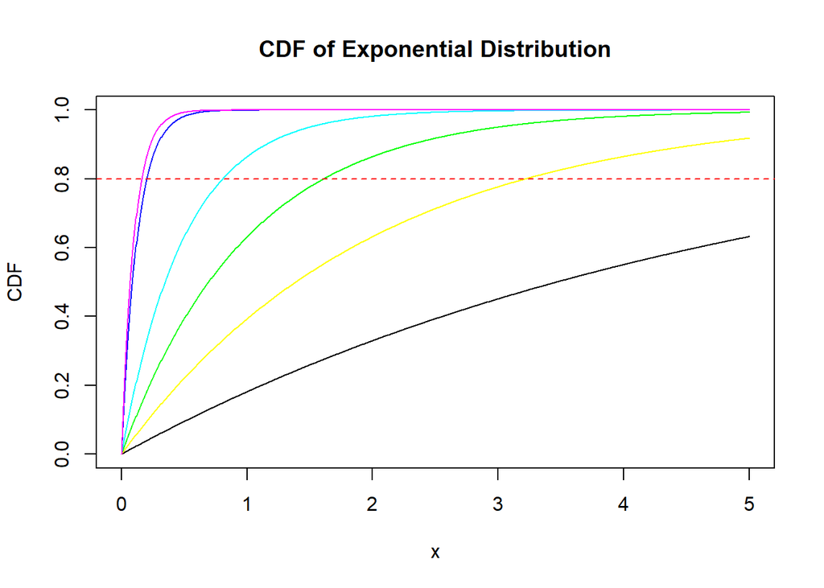

```r
lambda_values <- c(0.2, 0.5, 1, 2, 8, 10)

x_values <- seq(0, 5, length.out = 1000)

plot(x_values, pexp(x_values, rate = lambda_values[1]), type = "l",
     col = "black", ylim = c(0, 1),
     xlab = "x", ylab = "CDF",
     main = "CDF of Exponential Distribution")

for (lambda in lambda_values[-1]) {
  lines(x_values, pexp(x_values, rate = lambda), col = rainbow(length(lambda_values))[which(lambda_values == lambda)])
}

abline(h = 0.8, col = "red", lty = 2)
```

## 5.2 Cummulative Distribution Function

For values of $\lambda$ in $(0.2, 0.5, 1, 2, 8, 10)$ plot the graphs of the cumulative distribution function of $\text{Exp}(\lambda)$ in the same plot. Draw a horizontal line at $y=0.8$.

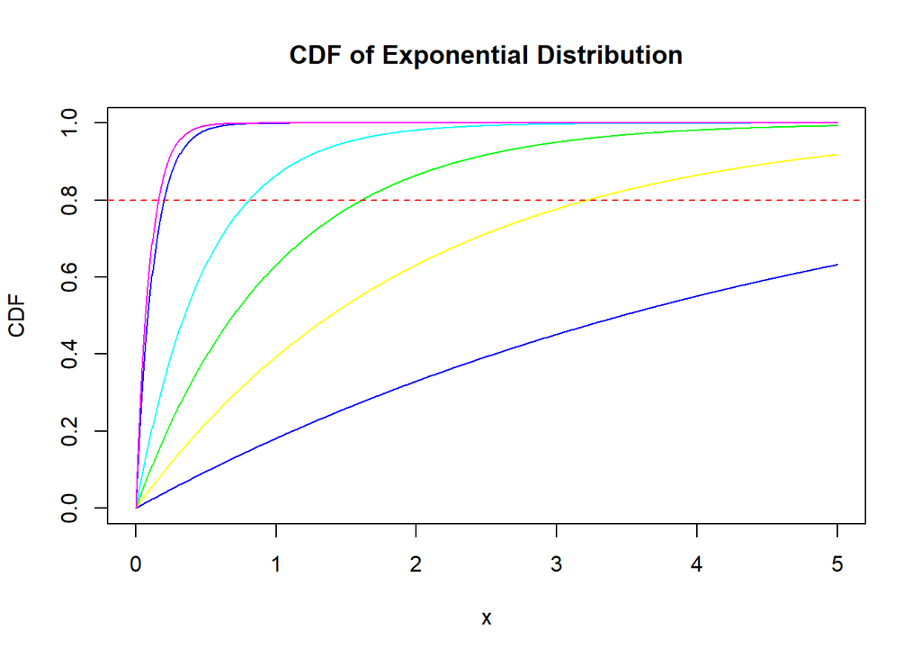

```r
plot_exp_cdf <- function(lambda_values) {
  x_values <- seq(0, 5, length.out = 1000)

  # Set up the plot
  plot(x_values, pexp(x_values, rate = lambda_values[1]), type = "l",
       col = "blue", ylim = c(0, 1),
       xlab = "x", ylab = "CDF",
       main = "CDF of Exponential Distribution")

  for (lambda in lambda_values[-1]) {
    lines(x_values, pexp(x_values, rate = lambda), col = rainbow(length(lambda_values))[which(lambda_values == lambda)])
  }

  abline(h = 0.8, col = "red", lty = 2)
}

plot_exp_cdf(c(0.2, 0.5, 1, 2, 8, 10))
```

# 6 Gamma Distibution

We will plot the Gamma distribution for different shapes and scales. You might need to adjust the limits of x and y axes appropriately.

## 6.1 Different Shapes

```r
x <- seq(0, 10, length.out = 1000)
```

```r
y_0.3 <- dgamma(x, shape = 0.3, scale = 1)
y_0.7 <- dgamma(x, shape = 0.7, scale = 1)
y_1 <- dgamma(x, shape = 1, scale = 1)
y_1.5 <- dgamma(x, shape = 1.5, scale = 1)
y_2 <- dgamma(x, shape = 2, scale = 1)
y_2.5 <- dgamma(x, shape = 2.5, scale = 1)
#y_10 <- dgamma(x, shape = 10, scale = 1)

plot_data_pdf <- data.frame(x,y_1,y_1.5,y_2, y_2.5)
```

```r
plot_data_pdf_new <- pivot_longer(plot_data_pdf,
                                  cols = c(y_1,y_1.5,y_2, y_2.5),
                                  names_to = "shapes"
                                  )
```

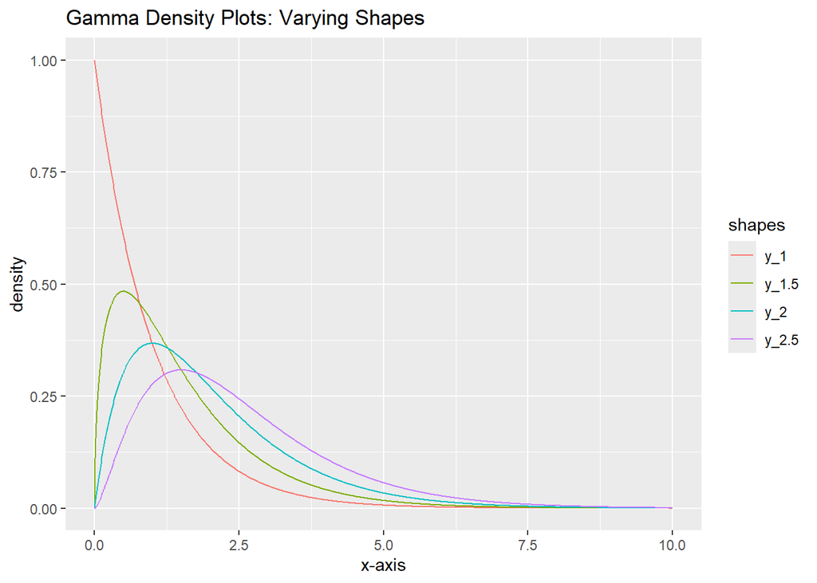

```r
ggplot(data = plot_data_pdf_new,
  aes(x = x,
      y = value,
      group = shapes,
      color = shapes))+
  geom_line()+
  labs(title = "Gamma Density Plots: Varying Shapes",
       x = "x-axis",
       y = "density")
```

## 6.2 $\alpha =1$ , varying scales

Set $\alpha = 1$, vary $\beta$ over $0.2, 0.6, 1, 1.5, 2$. Plot the densities of $\text{Gamma}(\alpha, \beta)$ in a single plot.

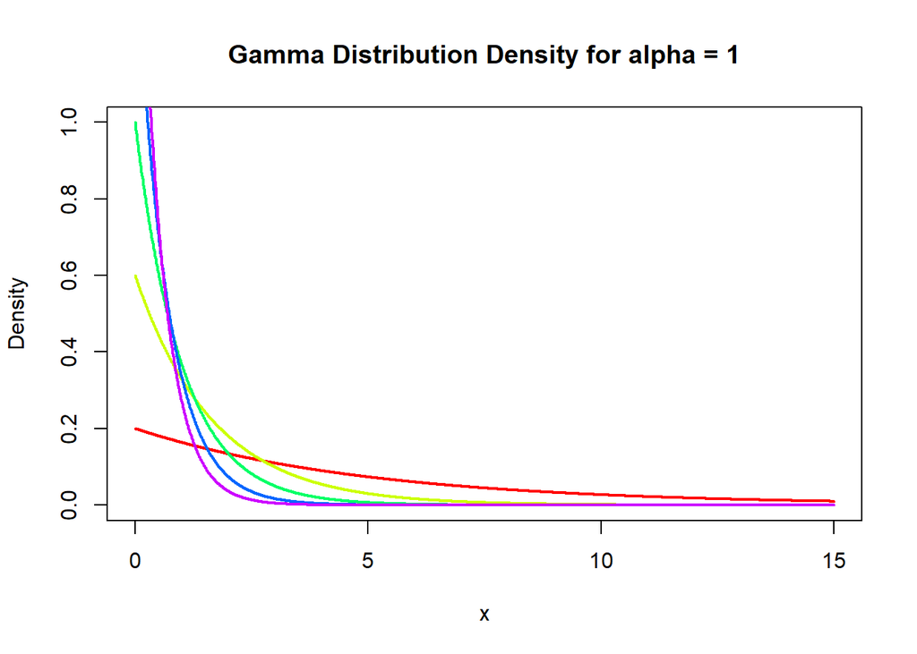

```r
plot_gamma_density <- function(alpha, beta_values) {
  x <- seq(0, 15, by = 0.01)

  plot(x, dgamma(x, shape = alpha, rate = beta_values[1]), type = "n",
       xlab = "x", ylab = "Density",
       main = paste("Gamma Distribution Density for alpha =", alpha),
       ylim = c(0, 1))

  for (beta in beta_values) {
    lines(x, dgamma(x, shape = alpha, rate = beta),
          col = rainbow(length(beta_values))[which(beta_values == beta)],
          lwd = 2)
  }

}
  beta_values <- c(0.2, 0.6, 1, 1.5, 2)
  plot_gamma_density(1, beta_values)
```

## 6.3 $\alpha =0.6$ , varying scales

Set $\alpha = 0.6$, vary $\beta$ over $0.2, 0.6, 1, 1.5, 2$. Plot the densities of $\text{Gamma}(\alpha, \beta)$ in a single plot.

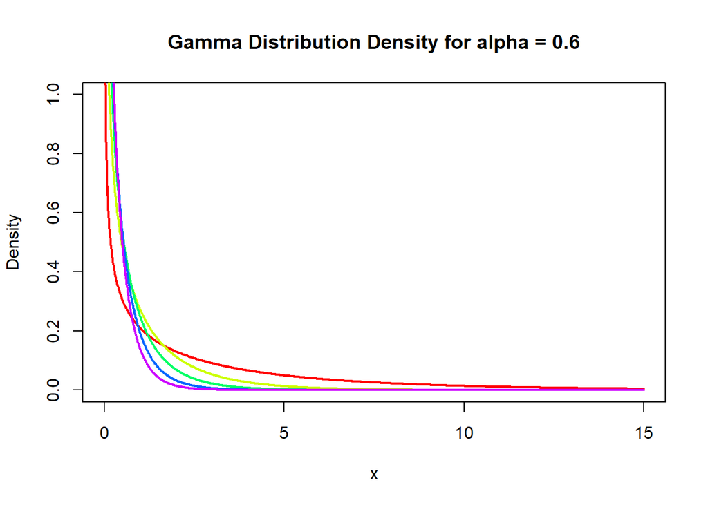

```r
beta_values <- c(0.2, 0.6, 1, 1.5, 2)
  plot_gamma_density(.6, beta_values)
```

## 6.4 $\alpha = 2$ , varying scales

Set $\alpha = 2$, vary $\beta$ over $0.2, 0.6, 1, 1.5, 2$. Plot the densities of $\text{Gamma}(\alpha, \beta)$ in a single plot.

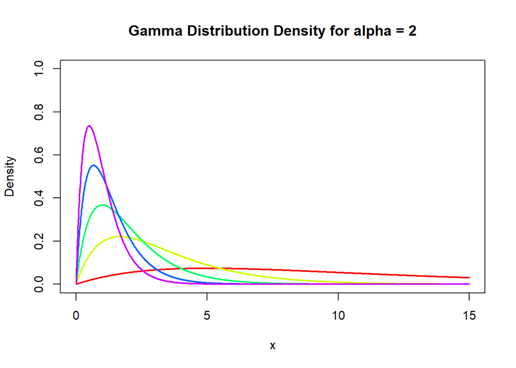

```r
beta_values <- c(0.2, 0.6, 1, 1.5, 2)
  plot_gamma_density(2, beta_values)
```

## 6.5 $\alpha = 5$ , varying scales

Set $\alpha = 5$, vary $\beta$ over $0.2, 0.6, 1, 1.5, 2$. Plot the densities of $\text{Gamma}(\alpha, \beta)$ in a single plot.

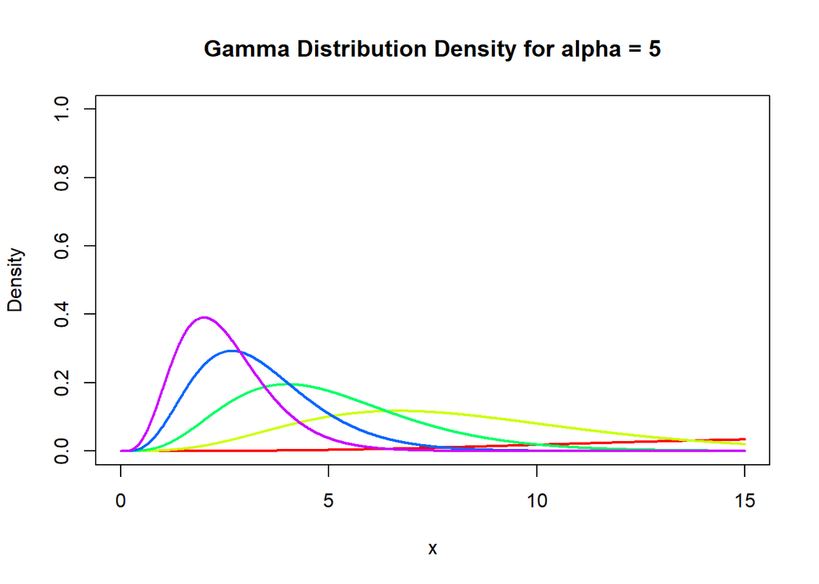

```r
beta_values <- c(0.2, 0.6, 1, 1.5, 2)
  plot_gamma_density(5, beta_values)
```